# Multi-Group Confirmatory Factor Analysis

# Multigroup Models

- Let’s start with some terminology specific to multigroup models: invariance = equivalence
- Under different conditions, do the measurements yield the same measurement of attributes?
- Generally, we’ve seen that latent variable models are estimating the data based on the covariances. For these models, we will also add the mean structure.
- While you can test many groups in these models, you will want to generally compare two at a time.

# Mean Structure

- Mean structure represents the intercept of our manifest variables
- In regression, remember that the Y-intercept is the mean of Y (given X = 0 or no X variables)
  - That’s your best guess for what someone is going to score on that item without any other X information
  - Same idea in a latent variable model - it’s the starting value for that manifest variable.

# Latent Means

- Latent means are the estimated score on the latent variable for participants.
- It’s a weighted score of each item’s original value with their path coefficient, and all items are averaged together.
- We can use `lavPredict()` to calculate these for us.

# Multigroup Questions

- Do items act the same across groups?
- Is the factor structure the same across groups?
- Are the paths equal across groups?
- Are the latent means equal across groups?

# How to MG

- First, test the model as a regular CFA with everyone in the dataset
  - This model will tell you if you have problems with your CFA
  - This model is the least restrictive
  - Do not use grouping variables

# How to MG

- Second, test each group separately with the same CFA structure to determine that each individual group fits ok.
- Fit indices often decrease slightly here, because sample size is smaller (which usually has a bit more error variance).
- Mainly, you are looking for models that completely break down
  - You could have a poor fitting CFA overall and use this step to see if that’s because one group just does not fit.

# How to MG

- The next steps will be to nest the two models together.
- Nesting is like stacking the models together (like pancakes).
- For the nested model steps, most people use Brown’s terminology and procedure.

# How to MG

- All the possible paths:
  - The whole model (the picture)
  - Loadings (regression weights)
  - Intercepts (y-intercept for each item)
  - Error variances (variance)
  - Factor variances (variances for the latents)
  - Factor covariances (correlation)
  - Factor means (latent means)

# Equal Form / Configural Invariance

- In this model, you put the two groups together into the same model.
- You do not force any of the paths to be the same, but you are forcing the model picture to be the same.
- You are testing if both groups show the same factor structure (configuration).

# Metric Invariance

- In this model, you are forcing all the factor loadings (regression weights) to be exactly the same.
- This step will tell you if the groups have the same weights for each question – or if some questions have different signs or strengths.

# Scalar Invariance

- In this model, you are forcing the intercepts of the items to be the same.
- This step will tell you if items have the same starting point – remember that the y-intercept is the mean of the item.
- If a MG model is going to indicate non-invariance – this step is often the one that breaks.

# Strict Factorial Invariance

- In this model, you are forcing the error variances for each item to be the same.
- This step will tell you if the variance (the spread) of the item is the same for each group.
- If you get differences, that indicates one group has a larger range of answers than another, which indicates they are more heterogeneous.

# Other Steps

- Most of the previous steps are on the manifest/measured variables only.
- Generally, we focus on those because they indicate performance of the scale.
- Population Heterogeneity:
  - Equal factor variances: Testing if latents have the same set of variance – means that the overall score has the same spread
  - Equal factor covariances: Testing if the correlations between factors is the same for each group
  - Equal latent means: Testing if the overall latent means are equal for each group

# How to Judge

- How can I tell if steps are invariant?
- You will expect fit to get worse as you go because you are being more and more restrictive.
- While we can use change in $\chi^2$, most suggest a change in CFI > .01 to be a difference in fit.

# Model Breakdown

- What do I do if steps are NOT invariant?
- Partial invariance – when strict invariance cannot be met, you can test for partial invariance
- Partial invariance occurs when most of the items are invariant but a couple.
- You have to meet the invariance criteria, so you trying to bring your bad model “up” to the invariant level
- You want to do as few of items as possible

# Partial Invariance

- So, how do I test partial invariance?
- We can use modification indices to see which paths are the most problematic.
- You will change ONE item at a time.
- Slowly add items to bring CFI up to an acceptable change level (i.e. .01 or less change from the previous model).

# Test Latent Means

- After saying the measured variables are partially to fully invariant, sometimes people also calculate latent means and use *t*-tests to determine if they are different by groups.
  - Instead of doing all the population heterogeneity steps.
- At the minimum, it is useful to know how to calculate a weighted score for each participant.
- We normally use EFA/CFA to show that each question has a nice loading and the questions load together
- And then we use subtotals or averages to create an overall score for each latent
  - This procedure totally ignores the fact that loadings are often different.
  - Why lose that information?

# Let’s get started!

- Equality constraints
- We’ve talked before about setting paths equal to each other by calling them the same parameter name
  - `cheese =~ a\*feta + a\*swiss`
  - So feta and swiss will be estimated at the same value.
- The entire purpose of a multigroup model is to build equality constraints
- A few packages used to do this … but have become more trouble than they are worth, so let’s look at how to do these steps with just `lavaan`.

# An Example

- Using the RS-14 scale: a one-factor measure of resiliency

```r
library(lavaan)
library(rio)
res.data <- import("data/assignment_mgcfa.csv")

head(res.data)
```

```
#>   Sex Ethnicity RS1 RS2 RS3 RS4 RS5 RS6 RS7 RS8 RS9 RS10
#> 1   2         0   4   4   4   4   4   4   4   4   4    4
#> 2   1         0   5   2   6   4   4   5   4   5   5    4
#> 3   2         0   7   7   7   7   2   7   7   4   3    7
#> 4   2         0   7   6   6   7   7   7   7   7   7    7
#> 5   1         0   2   2   2   2   2   2   2   2   2    2
#> 6   2         0   4   5   5   7   5   7   5   7   5    4
#>   RS11 RS12 RS13 RS14
#> 1    4    4    4    4
#> 2    4    6    4    4
#> 3    7    5    7    5
#> 4    7    6    7    7
#> 5    2    2    2    2
#> 6    5    6    6    5
```

# Clean up the data

- By not including other labels, we are dropping those categories

```r
table(res.data$Sex)
```

```
#>
#>   1   2   3
#> 244 266   1
```

```r
res.data$Sex <- factor(res.data$Sex,
                       levels = c(1,2),
                       labels = c("Men", "Women"))
res.data <- subset(res.data, !is.na(Sex))
nrow(res.data)
```

```
#> [1] 510
```

# Start with Overall CFA

- NEW: `meanstructure = TRUE`
- Gives you the intercepts and means in the model.
- You want to turn that one at the beginning, and you are first examining models with means, so you can tell if you have bad parameters at the start.

# Start with Overall CFA

```r
overall.model <- '
RS =~ RS1 + RS2 + RS3 + RS4 + RS5 + RS6 + RS7 + RS8 + RS9 + RS10 + RS11 + RS12 + RS13 + RS14
'

overall.fit <- cfa(model = overall.model,
                   data = res.data,
                   meanstructure = TRUE) ##this is important
```

# Examine Overall Fit

```r
summary(overall.fit,
        standardized = TRUE,
        rsquare = TRUE,
        fit.measure = TRUE)
```

```
#> lavaan 0.6-19 ended normally after 26 iterations
#>
#>   Estimator                                         ML
#>   Optimization method                           NLMINB
#>   Number of model parameters                        42
#>
#>   Number of observations                           510
#>
#> Model Test User Model:
#>
#>   Test statistic                               368.984
#>   Degrees of freedom                                77
#>   P-value (Chi-square)                           0.000
#>
#> Model Test Baseline Model:
#>
#>   Test statistic                              4064.761
#>   Degrees of freedom                                91
#>   P-value                                        0.000
#>
#> User Model versus Baseline Model:
#>
#>   Comparative Fit Index (CFI)                    0.927
#>   Tucker-Lewis Index (TLI)                       0.913
#>
#> Loglikelihood and Information Criteria:
#>
#>   Loglikelihood user model (H0)             -13050.226
#>   Loglikelihood unrestricted model (H1)     -12865.734
#>
#>   Akaike (AIC)                               26184.452
#>   Bayesian (BIC)                             26362.297
#>   Sample-size adjusted Bayesian (SABIC)      26228.983
#>
#> Root Mean Square Error of Approximation:
#>
#>   RMSEA                                          0.086
#>   90 Percent confidence interval - lower         0.078
#>   90 Percent confidence interval - upper         0.095
#>   P-value H_0: RMSEA <= 0.050                    0.000
```

[output cut: 113 more lines]

```
#>                    Estimate
#>     RS1               0.406
#>     RS2               0.470
#>     RS3               0.411
#>     RS4               0.438
#>     RS5               0.414
#>     RS6               0.535
#>     RS7               0.564
#>     RS8               0.497
#>     RS9               0.555
#>     RS10              0.507
#>     RS11              0.561
#>     RS12              0.467
#>     RS13              0.572
#>     RS14              0.675
```

# Make a table of fit indices

```r
library(knitr)
table_fit <- matrix(NA, nrow = 9, ncol = 6)
colnames(table_fit) = c("Model", "X2", "df", "CFI", "RMSEA", "SRMR")
table_fit[1, ] <- c("Overall Model", round(fitmeasures(overall.fit,
                                                 c("chisq", "df", "cfi",
                                                   "rmsea", "srmr")),3))
kable(table_fit)
```

| Model | X2 | df | CFI | RMSEA | SRMR |
| --- | --- | --- | --- | --- | --- |
| Overall Model | 368.984 | 77 | 0.927 | 0.086 | 0.041 |
| NA | NA | NA | NA | NA | NA |
| NA | NA | NA | NA | NA | NA |
| NA | NA | NA | NA | NA | NA |
| NA | NA | NA | NA | NA | NA |
| NA | NA | NA | NA | NA | NA |
| NA | NA | NA | NA | NA | NA |
| NA | NA | NA | NA | NA | NA |
| NA | NA | NA | NA | NA | NA |

# Create a Picture

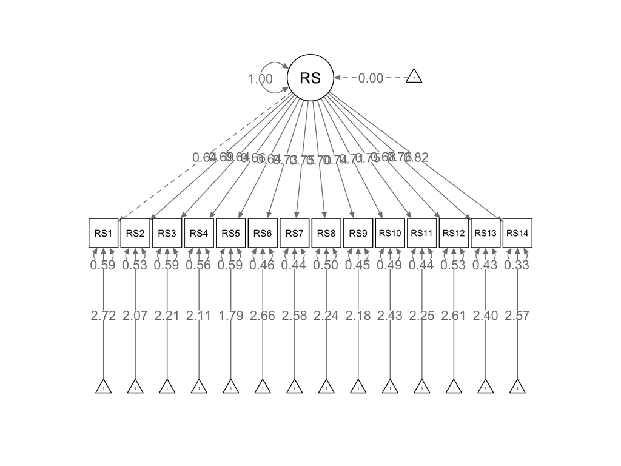

```r
library(semPlot)

semPaths(overall.fit,
         whatLabels = "std",
         edge.label.cex = 1,
         layout = "tree")
```

# Men Overall Summary

```r
men.fit <- cfa(model = overall.model,
               data = res.data[res.data$Sex == "Men" , ],
               meanstructure = TRUE)
summary(men.fit,
        standardized = TRUE,
        rsquare = TRUE,
        fit.measure = TRUE)
```

```
#> lavaan 0.6-19 ended normally after 25 iterations
#>
#>   Estimator                                         ML
#>   Optimization method                           NLMINB
#>   Number of model parameters                        42
#>
#>   Number of observations                           244
#>
#> Model Test User Model:
#>
#>   Test statistic                               271.457
#>   Degrees of freedom                                77
#>   P-value (Chi-square)                           0.000
#>
#> Model Test Baseline Model:
#>
#>   Test statistic                              2515.572
#>   Degrees of freedom                                91
#>   P-value                                        0.000
#>
#> User Model versus Baseline Model:
#>
#>   Comparative Fit Index (CFI)                    0.920
#>   Tucker-Lewis Index (TLI)                       0.905
#>
#> Loglikelihood and Information Criteria:
#>
#>   Loglikelihood user model (H0)              -6043.672
#>   Loglikelihood unrestricted model (H1)      -5907.944
#>
#>   Akaike (AIC)                               12171.345
#>   Bayesian (BIC)                             12318.226
#>   Sample-size adjusted Bayesian (SABIC)      12185.091
#>
#> Root Mean Square Error of Approximation:
#>
#>   RMSEA                                          0.102
#>   90 Percent confidence interval - lower         0.089
#>   90 Percent confidence interval - upper         0.115
#>   P-value H_0: RMSEA <= 0.050                    0.000
```

[output cut: 113 more lines]

```
#>                    Estimate
#>     RS1               0.491
#>     RS2               0.570
#>     RS3               0.482
#>     RS4               0.485
#>     RS5               0.454
#>     RS6               0.543
#>     RS7               0.554
#>     RS8               0.617
#>     RS9               0.664
#>     RS10              0.570
#>     RS11              0.612
#>     RS12              0.625
#>     RS13              0.695
#>     RS14              0.700
```

# Women Overall Summary

```r
women.fit <- cfa(model = overall.model,
                 data = res.data[res.data$Sex == "Women" , ],
                 meanstructure = TRUE)
summary(women.fit,
        standardized = TRUE,
        rsquare = TRUE,
        fit.measure = TRUE)
```

```
#> lavaan 0.6-19 ended normally after 29 iterations
#>
#>   Estimator                                         ML
#>   Optimization method                           NLMINB
#>   Number of model parameters                        42
#>
#>   Number of observations                           266
#>
#> Model Test User Model:
#>
#>   Test statistic                               258.610
#>   Degrees of freedom                                77
#>   P-value (Chi-square)                           0.000
#>
#> Model Test Baseline Model:
#>
#>   Test statistic                              1813.360
#>   Degrees of freedom                                91
#>   P-value                                        0.000
#>
#> User Model versus Baseline Model:
#>
#>   Comparative Fit Index (CFI)                    0.895
#>   Tucker-Lewis Index (TLI)                       0.875
#>
#> Loglikelihood and Information Criteria:
#>
#>   Loglikelihood user model (H0)              -6938.738
#>   Loglikelihood unrestricted model (H1)      -6809.434
#>
#>   Akaike (AIC)                               13961.477
#>   Bayesian (BIC)                             14111.984
#>   Sample-size adjusted Bayesian (SABIC)      13978.820
#>
#> Root Mean Square Error of Approximation:
#>
#>   RMSEA                                          0.094
#>   90 Percent confidence interval - lower         0.082
#>   90 Percent confidence interval - upper         0.107
#>   P-value H_0: RMSEA <= 0.050                    0.000
```

[output cut: 113 more lines]

```
#>                    Estimate
#>     RS1               0.314
#>     RS2               0.369
#>     RS3               0.339
#>     RS4               0.404
#>     RS5               0.388
#>     RS6               0.538
#>     RS7               0.583
#>     RS8               0.389
#>     RS9               0.466
#>     RS10              0.446
#>     RS11              0.503
#>     RS12              0.331
#>     RS13              0.460
#>     RS14              0.660
```

# Add the fit to table

```r
table_fit[2, ] <- c("Men Model", round(fitmeasures(men.fit,
                                                 c("chisq", "df", "cfi",
                                                   "rmsea", "srmr")),3))

table_fit[3, ] <- c("Women Model", round(fitmeasures(women.fit,
                                                 c("chisq", "df", "cfi",
                                                   "rmsea", "srmr")),3))

kable(table_fit)
```

| Model | X2 | df | CFI | RMSEA | SRMR |
| --- | --- | --- | --- | --- | --- |
| Overall Model | 368.984 | 77 | 0.927 | 0.086 | 0.041 |
| Men Model | 271.457 | 77 | 0.92 | 0.102 | 0.041 |
| Women Model | 258.61 | 77 | 0.895 | 0.094 | 0.052 |
| NA | NA | NA | NA | NA | NA |
| NA | NA | NA | NA | NA | NA |
| NA | NA | NA | NA | NA | NA |
| NA | NA | NA | NA | NA | NA |
| NA | NA | NA | NA | NA | NA |
| NA | NA | NA | NA | NA | NA |

# Configural Invariance

- Both groups “pancaked” together

```r
configural.fit <- cfa(model = overall.model,
                      data = res.data,
                      meanstructure = TRUE,
                      group = "Sex")
summary(configural.fit,
        standardized = TRUE,
        rsquare = TRUE,
        fit.measure = TRUE)
```

```
#> lavaan 0.6-19 ended normally after 49 iterations
#>
#>   Estimator                                         ML
#>   Optimization method                           NLMINB
#>   Number of model parameters                        84
#>
#>   Number of observations per group:
#>     Women                                          266
#>     Men                                            244
#>
#> Model Test User Model:
#>
#>   Test statistic                               530.067
#>   Degrees of freedom                               154
#>   P-value (Chi-square)                           0.000
#>   Test statistic for each group:
#>     Women                                      258.610
#>     Men                                        271.457
#>
#> Model Test Baseline Model:
#>
#>   Test statistic                              4328.931
#>   Degrees of freedom                               182
#>   P-value                                        0.000
#>
#> User Model versus Baseline Model:
#>
#>   Comparative Fit Index (CFI)                    0.909
#>   Tucker-Lewis Index (TLI)                       0.893
#>
#> Loglikelihood and Information Criteria:
#>
#>   Loglikelihood user model (H0)             -12982.411
#>   Loglikelihood unrestricted model (H1)     -12717.377
#>
#>   Akaike (AIC)                               26132.822
#>   Bayesian (BIC)                             26488.512
#>   Sample-size adjusted Bayesian (SABIC)      26221.885
#>
#> Root Mean Square Error of Approximation:
```

[output cut: 241 more lines]

```
#>                    Estimate
#>     RS1               0.491
#>     RS2               0.570
#>     RS3               0.482
#>     RS4               0.485
#>     RS5               0.454
#>     RS6               0.543
#>     RS7               0.554
#>     RS8               0.617
#>     RS9               0.664
#>     RS10              0.570
#>     RS11              0.612
#>     RS12              0.625
#>     RS13              0.695
#>     RS14              0.700
```

# Add the fit to table

```r
table_fit[4, ] <- c("Configural Model", round(fitmeasures(configural.fit,
                                                 c("chisq", "df", "cfi",
                                                   "rmsea", "srmr")),3))

kable(table_fit)
```

| Model | X2 | df | CFI | RMSEA | SRMR |
| --- | --- | --- | --- | --- | --- |
| Overall Model | 368.984 | 77 | 0.927 | 0.086 | 0.041 |
| Men Model | 271.457 | 77 | 0.92 | 0.102 | 0.041 |
| Women Model | 258.61 | 77 | 0.895 | 0.094 | 0.052 |
| Configural Model | 530.067 | 154 | 0.909 | 0.098 | 0.047 |
| NA | NA | NA | NA | NA | NA |
| NA | NA | NA | NA | NA | NA |
| NA | NA | NA | NA | NA | NA |
| NA | NA | NA | NA | NA | NA |
| NA | NA | NA | NA | NA | NA |

# Metric Invariance

- Are the factor loadings the same?

```r
metric.fit <- cfa(model = overall.model,
                  data = res.data,
                  meanstructure = TRUE,
                  group = "Sex",
                  group.equal = c("loadings"))
summary(metric.fit,
        standardized = TRUE,
        rsquare = TRUE,
        fit.measure = TRUE)
```

```
#> lavaan 0.6-19 ended normally after 36 iterations
#>
#>   Estimator                                         ML
#>   Optimization method                           NLMINB
#>   Number of model parameters                        84
#>   Number of equality constraints                    13
#>
#>   Number of observations per group:
#>     Women                                          266
#>     Men                                            244
#>
#> Model Test User Model:
#>
#>   Test statistic                               545.518
#>   Degrees of freedom                               167
#>   P-value (Chi-square)                           0.000
#>   Test statistic for each group:
#>     Women                                      268.133
#>     Men                                        277.385
#>
#> Model Test Baseline Model:
#>
#>   Test statistic                              4328.931
#>   Degrees of freedom                               182
#>   P-value                                        0.000
#>
#> User Model versus Baseline Model:
#>
#>   Comparative Fit Index (CFI)                    0.909
#>   Tucker-Lewis Index (TLI)                       0.901
#>
#> Loglikelihood and Information Criteria:
#>
#>   Loglikelihood user model (H0)             -12990.137
#>   Loglikelihood unrestricted model (H1)     -12717.377
#>
#>   Akaike (AIC)                               26122.273
#>   Bayesian (BIC)                             26422.916
#>   Sample-size adjusted Bayesian (SABIC)      26197.552
#>
```

[output cut: 242 more lines]

```
#>                    Estimate
#>     RS1               0.463
#>     RS2               0.561
#>     RS3               0.479
#>     RS4               0.501
#>     RS5               0.473
#>     RS6               0.560
#>     RS7               0.588
#>     RS8               0.603
#>     RS9               0.664
#>     RS10              0.579
#>     RS11              0.631
#>     RS12              0.583
#>     RS13              0.681
#>     RS14              0.699
```

# Add the fit to table

```r
table_fit[5, ] <- c("Metric Model", round(fitmeasures(metric.fit,
                                                 c("chisq", "df", "cfi",
                                                   "rmsea", "srmr")),3))

kable(table_fit)
```

| Model | X2 | df | CFI | RMSEA | SRMR |
| --- | --- | --- | --- | --- | --- |
| Overall Model | 368.984 | 77 | 0.927 | 0.086 | 0.041 |
| Men Model | 271.457 | 77 | 0.92 | 0.102 | 0.041 |
| Women Model | 258.61 | 77 | 0.895 | 0.094 | 0.052 |
| Configural Model | 530.067 | 154 | 0.909 | 0.098 | 0.047 |
| Metric Model | 545.518 | 167 | 0.909 | 0.094 | 0.057 |
| NA | NA | NA | NA | NA | NA |
| NA | NA | NA | NA | NA | NA |
| NA | NA | NA | NA | NA | NA |
| NA | NA | NA | NA | NA | NA |

# Scalar Invariance

- Are the item intercepts the same?

```r
scalar.fit <- cfa(model = overall.model,
                  data = res.data,
                  meanstructure = TRUE,
                  group = "Sex",
                  group.equal = c("loadings", "intercepts"))
summary(scalar.fit,
        standardized = TRUE,
        rsquare = TRUE,
        fit.measure = TRUE)
```

```
#> lavaan 0.6-19 ended normally after 47 iterations
#>
#>   Estimator                                         ML
#>   Optimization method                           NLMINB
#>   Number of model parameters                        85
#>   Number of equality constraints                    27
#>
#>   Number of observations per group:
#>     Women                                          266
#>     Men                                            244
#>
#> Model Test User Model:
#>
#>   Test statistic                               585.327
#>   Degrees of freedom                               180
#>   P-value (Chi-square)                           0.000
#>   Test statistic for each group:
#>     Women                                      289.405
#>     Men                                        295.921
#>
#> Model Test Baseline Model:
#>
#>   Test statistic                              4328.931
#>   Degrees of freedom                               182
#>   P-value                                        0.000
#>
#> User Model versus Baseline Model:
#>
#>   Comparative Fit Index (CFI)                    0.902
#>   Tucker-Lewis Index (TLI)                       0.901
#>
#> Loglikelihood and Information Criteria:
#>
#>   Loglikelihood user model (H0)             -13010.041
#>   Loglikelihood unrestricted model (H1)     -12717.377
#>
#>   Akaike (AIC)                               26136.082
#>   Bayesian (BIC)                             26381.678
#>   Sample-size adjusted Bayesian (SABIC)      26197.577
#>
```

[output cut: 244 more lines]

```
#>                    Estimate
#>     RS1               0.462
#>     RS2               0.561
#>     RS3               0.476
#>     RS4               0.494
#>     RS5               0.467
#>     RS6               0.558
#>     RS7               0.588
#>     RS8               0.600
#>     RS9               0.662
#>     RS10              0.579
#>     RS11              0.631
#>     RS12              0.582
#>     RS13              0.681
#>     RS14              0.700
```

# Add the fit to table

```r
table_fit[6, ] <- c("Scalar Model", round(fitmeasures(scalar.fit,
                                                 c("chisq", "df", "cfi",
                                                   "rmsea", "srmr")),3))

kable(table_fit)
```

| Model | X2 | df | CFI | RMSEA | SRMR |
| --- | --- | --- | --- | --- | --- |
| Overall Model | 368.984 | 77 | 0.927 | 0.086 | 0.041 |
| Men Model | 271.457 | 77 | 0.92 | 0.102 | 0.041 |
| Women Model | 258.61 | 77 | 0.895 | 0.094 | 0.052 |
| Configural Model | 530.067 | 154 | 0.909 | 0.098 | 0.047 |
| Metric Model | 545.518 | 167 | 0.909 | 0.094 | 0.057 |
| Scalar Model | 585.327 | 180 | 0.902 | 0.094 | 0.06 |
| NA | NA | NA | NA | NA | NA |
| NA | NA | NA | NA | NA | NA |
| NA | NA | NA | NA | NA | NA |

# Strict (Error) Invariance

- Are the item residuals the same?

```r
strict.fit <- cfa(model = overall.model,
                  data = res.data,
                  meanstructure = TRUE,
                  group = "Sex",
                  group.equal = c("loadings", "intercepts", "residuals"))
summary(strict.fit,
        standardized = TRUE,
        rsquare = TRUE,
        fit.measure = TRUE)
```

```
#> lavaan 0.6-19 ended normally after 46 iterations
#>
#>   Estimator                                         ML
#>   Optimization method                           NLMINB
#>   Number of model parameters                        85
#>   Number of equality constraints                    41
#>
#>   Number of observations per group:
#>     Women                                          266
#>     Men                                            244
#>
#> Model Test User Model:
#>
#>   Test statistic                               660.398
#>   Degrees of freedom                               194
#>   P-value (Chi-square)                           0.000
#>   Test statistic for each group:
#>     Women                                      314.816
#>     Men                                        345.582
#>
#> Model Test Baseline Model:
#>
#>   Test statistic                              4328.931
#>   Degrees of freedom                               182
#>   P-value                                        0.000
#>
#> User Model versus Baseline Model:
#>
#>   Comparative Fit Index (CFI)                    0.888
#>   Tucker-Lewis Index (TLI)                       0.894
#>
#> Loglikelihood and Information Criteria:
#>
#>   Loglikelihood user model (H0)             -13047.576
#>   Loglikelihood unrestricted model (H1)     -12717.377
#>
#>   Akaike (AIC)                               26183.153
#>   Bayesian (BIC)                             26369.467
#>   Sample-size adjusted Bayesian (SABIC)      26229.805
#>
```

[output cut: 244 more lines]

```
#>                    Estimate
#>     RS1               0.442
#>     RS2               0.506
#>     RS3               0.447
#>     RS4               0.474
#>     RS5               0.449
#>     RS6               0.571
#>     RS7               0.599
#>     RS8               0.533
#>     RS9               0.590
#>     RS10              0.542
#>     RS11              0.596
#>     RS12              0.504
#>     RS13              0.608
#>     RS14              0.706
```

# Add the fit to table

```r
table_fit[7, ] <- c("Strict Model", round(fitmeasures(strict.fit,
                                                 c("chisq", "df", "cfi",
                                                   "rmsea", "srmr")),3))

kable(table_fit)
```

| Model | X2 | df | CFI | RMSEA | SRMR |
| --- | --- | --- | --- | --- | --- |
| Overall Model | 368.984 | 77 | 0.927 | 0.086 | 0.041 |
| Men Model | 271.457 | 77 | 0.92 | 0.102 | 0.041 |
| Women Model | 258.61 | 77 | 0.895 | 0.094 | 0.052 |
| Configural Model | 530.067 | 154 | 0.909 | 0.098 | 0.047 |
| Metric Model | 545.518 | 167 | 0.909 | 0.094 | 0.057 |
| Scalar Model | 585.327 | 180 | 0.902 | 0.094 | 0.06 |
| Strict Model | 660.398 | 194 | 0.888 | 0.097 | 0.062 |
| NA | NA | NA | NA | NA | NA |
| NA | NA | NA | NA | NA | NA |

# Partial Invariance

- We can see in this last step that we have a difference in models based on change in CFI.
- Now, we have to figure out where the problem is and update our model to fix that problem.
- You would only look for problems *in the step you are in*.

# Partial Invariance

- Figure out which level you need:
  - metric `=~` for loadings
  - scalar `~1` for intercepts
  - strict `~~` for variances
- Change each item one at a time and note the changes

# Partial Invariance

```r
##write out partial codes
partial_syntax <- paste(colnames(res.data)[3:16], #all the columns
                        "~~", #residuals
                        colnames(res.data)[3:16]) #all columns again
partial_syntax
```

```
#>  [1] "RS1 ~~ RS1"   "RS2 ~~ RS2"   "RS3 ~~ RS3"
#>  [4] "RS4 ~~ RS4"   "RS5 ~~ RS5"   "RS6 ~~ RS6"
#>  [7] "RS7 ~~ RS7"   "RS8 ~~ RS8"   "RS9 ~~ RS9"
#> [10] "RS10 ~~ RS10" "RS11 ~~ RS11" "RS12 ~~ RS12"
#> [13] "RS13 ~~ RS13" "RS14 ~~ RS14"
```

```r
CFI_list  <- 1:length(partial_syntax)
names(CFI_list) <- partial_syntax

for (i in 1:length(partial_syntax)){

  temp <- cfa(model = overall.model,
              data = res.data,
              meanstructure = TRUE,
              group = "Sex",
              group.equal = c("loadings", "intercepts", "residuals"),
              group.partial = partial_syntax[i])

  CFI_list[i] <- fitmeasures(temp, "cfi")
}

CFI_list
```

```
#>   RS1 ~~ RS1   RS2 ~~ RS2   RS3 ~~ RS3   RS4 ~~ RS4
#>    0.8877040    0.8892794    0.8881315    0.8876596
#>   RS5 ~~ RS5   RS6 ~~ RS6   RS7 ~~ RS7   RS8 ~~ RS8
#>    0.8875493    0.8874662    0.8873667    0.8897416
#>   RS9 ~~ RS9 RS10 ~~ RS10 RS11 ~~ RS11 RS12 ~~ RS12
#>    0.8906278    0.8882753    0.8888421    0.8896339
#> RS13 ~~ RS13 RS14 ~~ RS14
#>    0.8905766    0.8873834
```

```r
which.max(CFI_list)
```

```
#> RS9 ~~ RS9
#>          9
```

# Free up those paramers!

```r
strict.fit2 <- cfa(model = overall.model,
                  data = res.data,
                  meanstructure = TRUE,
                  group = "Sex",
                  group.equal = c("loadings", "intercepts", "residuals"),
                  group.partial = c("RS9 ~~ RS9"))
summary(strict.fit2,
        standardized = TRUE,
        rsquare = TRUE,
        fit.measure = TRUE)
```

```
#> lavaan 0.6-19 ended normally after 48 iterations
#>
#>   Estimator                                         ML
#>   Optimization method                           NLMINB
#>   Number of model parameters                        85
#>   Number of equality constraints                    40
#>
#>   Number of observations per group:
#>     Women                                          266
#>     Men                                            244
#>
#> Model Test User Model:
#>
#>   Test statistic                               646.559
#>   Degrees of freedom                               193
#>   P-value (Chi-square)                           0.000
#>   Test statistic for each group:
#>     Women                                      310.363
#>     Men                                        336.196
#>
#> Model Test Baseline Model:
#>
#>   Test statistic                              4328.931
#>   Degrees of freedom                               182
#>   P-value                                        0.000
#>
#> User Model versus Baseline Model:
#>
#>   Comparative Fit Index (CFI)                    0.891
#>   Tucker-Lewis Index (TLI)                       0.897
#>
#> Loglikelihood and Information Criteria:
#>
#>   Loglikelihood user model (H0)             -13040.657
#>   Loglikelihood unrestricted model (H1)     -12717.377
#>
#>   Akaike (AIC)                               26171.314
#>   Bayesian (BIC)                             26361.863
#>   Sample-size adjusted Bayesian (SABIC)      26219.026
#>
```

[output cut: 244 more lines]

```
#>                    Estimate
#>     RS1               0.441
#>     RS2               0.506
#>     RS3               0.447
#>     RS4               0.475
#>     RS5               0.449
#>     RS6               0.572
#>     RS7               0.599
#>     RS8               0.533
#>     RS9               0.660
#>     RS10              0.544
#>     RS11              0.594
#>     RS12              0.507
#>     RS13              0.609
#>     RS14              0.706
```

# Add the fit to table

```r
table_fit[8, ] <- c("Strict Model RS9", round(fitmeasures(strict.fit2,
                                                 c("chisq", "df", "cfi",
                                                   "rmsea", "srmr")),3))

kable(table_fit)
```

| Model | X2 | df | CFI | RMSEA | SRMR |
| --- | --- | --- | --- | --- | --- |
| Overall Model | 368.984 | 77 | 0.927 | 0.086 | 0.041 |
| Men Model | 271.457 | 77 | 0.92 | 0.102 | 0.041 |
| Women Model | 258.61 | 77 | 0.895 | 0.094 | 0.052 |
| Configural Model | 530.067 | 154 | 0.909 | 0.098 | 0.047 |
| Metric Model | 545.518 | 167 | 0.909 | 0.094 | 0.057 |
| Scalar Model | 585.327 | 180 | 0.902 | 0.094 | 0.06 |
| Strict Model | 660.398 | 194 | 0.888 | 0.097 | 0.062 |
| Strict Model RS9 | 646.559 | 193 | 0.891 | 0.096 | 0.062 |
| NA | NA | NA | NA | NA | NA |

# Find one more free parameter

- We want to see if we can get up to .902 - .01 = .892 for our CFI.

```r
for (i in 1:length(partial_syntax)){

  temp <- cfa(model = overall.model,
              data = res.data,
              meanstructure = TRUE,
              group = "Sex",
              group.equal = c("loadings", "intercepts", "residuals"),
              group.partial = c("RS9 ~~ RS9", partial_syntax[i]))

  CFI_list[i] <- fitmeasures(temp, "cfi")
}

CFI_list
```

```
#>   RS1 ~~ RS1   RS2 ~~ RS2   RS3 ~~ RS3   RS4 ~~ RS4
#>    0.8907350    0.8923563    0.8911657    0.8907125
#>   RS5 ~~ RS5   RS6 ~~ RS6   RS7 ~~ RS7   RS8 ~~ RS8
#>    0.8906552    0.8905857    0.8904937    0.8930016
#>   RS9 ~~ RS9 RS10 ~~ RS10 RS11 ~~ RS11 RS12 ~~ RS12
#>    0.8906278    0.8914713    0.8919005    0.8927904
#> RS13 ~~ RS13 RS14 ~~ RS14
#>    0.8936296    0.8904971
```

```r
which.max(CFI_list)
```

```
#> RS13 ~~ RS13
#>           13
```

# Add one more free parameter

```r
strict.fit3 <- cfa(model = overall.model,
                  data = res.data,
                  meanstructure = TRUE,
                  group = "Sex",
                  group.equal = c("loadings", "intercepts", "residuals"),
                  group.partial = c("RS9 ~~ RS9", "RS13 ~~ RS13"))
summary(strict.fit3,
        standardized = TRUE,
        rsquare = TRUE,
        fit.measure = TRUE)
```

```
#> lavaan 0.6-19 ended normally after 44 iterations
#>
#>   Estimator                                         ML
#>   Optimization method                           NLMINB
#>   Number of model parameters                        85
#>   Number of equality constraints                    39
#>
#>   Number of observations per group:
#>     Women                                          266
#>     Men                                            244
#>
#> Model Test User Model:
#>
#>   Test statistic                               633.111
#>   Degrees of freedom                               192
#>   P-value (Chi-square)                           0.000
#>   Test statistic for each group:
#>     Women                                      305.696
#>     Men                                        327.415
#>
#> Model Test Baseline Model:
#>
#>   Test statistic                              4328.931
#>   Degrees of freedom                               182
#>   P-value                                        0.000
#>
#> User Model versus Baseline Model:
#>
#>   Comparative Fit Index (CFI)                    0.894
#>   Tucker-Lewis Index (TLI)                       0.899
#>
#> Loglikelihood and Information Criteria:
#>
#>   Loglikelihood user model (H0)             -13033.933
#>   Loglikelihood unrestricted model (H1)     -12717.377
#>
#>   Akaike (AIC)                               26159.866
#>   Bayesian (BIC)                             26354.649
#>   Sample-size adjusted Bayesian (SABIC)      26208.638
#>
```

[output cut: 244 more lines]

```
#>                    Estimate
#>     RS1               0.442
#>     RS2               0.507
#>     RS3               0.445
#>     RS4               0.472
#>     RS5               0.450
#>     RS6               0.572
#>     RS7               0.600
#>     RS8               0.535
#>     RS9               0.661
#>     RS10              0.543
#>     RS11              0.592
#>     RS12              0.510
#>     RS13              0.683
#>     RS14              0.706
```

# Partial Invariance Met!

```r
table_fit[9, ] <- c("Strict Model RS9 + 13", round(fitmeasures(strict.fit3,
                                                 c("chisq", "df", "cfi",
                                                   "rmsea", "srmr")),3))

kable(table_fit)
```

| Model | X2 | df | CFI | RMSEA | SRMR |
| --- | --- | --- | --- | --- | --- |
| Overall Model | 368.984 | 77 | 0.927 | 0.086 | 0.041 |
| Men Model | 271.457 | 77 | 0.92 | 0.102 | 0.041 |
| Women Model | 258.61 | 77 | 0.895 | 0.094 | 0.052 |
| Configural Model | 530.067 | 154 | 0.909 | 0.098 | 0.047 |
| Metric Model | 545.518 | 167 | 0.909 | 0.094 | 0.057 |
| Scalar Model | 585.327 | 180 | 0.902 | 0.094 | 0.06 |
| Strict Model | 660.398 | 194 | 0.888 | 0.097 | 0.062 |
| Strict Model RS9 | 646.559 | 193 | 0.891 | 0.096 | 0.062 |
| Strict Model RS9 + 13 | 633.111 | 192 | 0.894 | 0.095 | 0.062 |

# Interpretation

- The RS is mostly invariant – the structure, loadings, intercepts, and most of the error variances are the same across men and women.
- However, two items show larger variances:
  - RS9
  - RS13
  - Where, women show much larger variances on both of those questions.
    - I keep interested in things.
    - My life has meaning.

# lavPredict on the items

```r
predicted_scores <- lavPredict(strict.fit3, type = "ov")

table(res.data$Sex)
```

```
#>
#>   Men Women
#>   244   266
```

```r
predicted_scores <- as.data.frame(do.call(rbind, predicted_scores))
predicted_scores$Sex <- c(rep("Women", 266), rep("Men", 244))

predicted_scores$sum <- apply(predicted_scores[ , 1:14], 1, sum)
head(predicted_scores)
```

```
#>        RS1      RS2      RS3      RS4      RS5      RS6
#> 1 4.398945 3.664178 3.685068 3.898936 3.267464 4.489343
#> 2 5.812096 5.401971 5.184889 5.632255 4.964156 6.209687
#> 3 6.517211 6.269071 5.933248 6.497123 5.810748 7.068081
#> 4 5.458156 4.966720 4.809240 5.198124 4.539199 5.778806
#> 5 4.051653 3.237102 3.316476 3.472960 2.850489 4.066555
#> 6 4.625009 3.942175 3.924997 4.176218 3.538887 4.764549
#>        RS7      RS8      RS9     RS10     RS11     RS12
#> 1 4.369067 3.807156 3.686699 4.085209 3.896680 4.482787
#> 2 6.153074 5.514666 5.479791 5.769280 5.747900 6.125213
#> 3 7.043233 6.366655 6.374483 6.609575 6.671596 6.944727
#> 4 5.706248 5.086999 5.030689 5.347484 5.284240 5.713847
#> 5 3.930633 3.387523 3.246033 3.671336 3.441728 4.079148
#> 6 4.654457 4.080309 3.973543 4.354613 4.192822 4.745528
#>       RS13     RS14   Sex      sum
#> 1 4.262883 4.148736 Women 56.14315
#> 2 6.201545 6.033519 Women 80.23004
#> 3 7.168871 6.973961 Women 92.24858
#> 4 5.715984 5.561452 Women 74.19719
#> 5 3.786442 3.685536 Women 50.22361
#> 6 4.573014 4.450247 Women 59.99637
```

```r
tapply(predicted_scores$sum, predicted_scores$Sex, mean)
```

```
#>      Men    Women
#> 63.34281 64.24733
```

# lavPredict on the factor scores

```r
res.data$sum <- apply(res.data[ , 3:16], 1, sum)

tapply(res.data$sum, res.data$Sex, mean)
```

```
#>      Men    Women
#> 63.47131 64.10902
```

```r
latent_means <- lavPredict(strict.fit3)

latent_means <- as.data.frame(do.call(rbind, latent_means))
latent_means$Sex <- c(rep("Women", 266), rep("Men", 244))

options(scipen = 999)
tapply(latent_means$RS, latent_means$Sex, mean)
```

```
#>              Men            Women
#> -0.0530675184545 -0.0000004953854
```

```r
tapply(latent_means$RS, latent_means$Sex, mean) * #latent mean
  tapply(res.data$sum, res.data$Sex, sd, na.rm = T) + #real sum
  tapply(res.data$sum, res.data$Sex, mean, na.rm = T) #real sd
```

```
#>      Men    Women
#> 62.32949 64.10901
```

# Calculate your favorite stat

```r
library(MOTE)
M <- tapply(predicted_scores$sum, predicted_scores$Sex, mean)
SD <- tapply(predicted_scores$sum, predicted_scores$Sex, sd)
N <- tapply(predicted_scores$sum, predicted_scores$Sex, length)

effect_size <- d.ind.t(M[1], M[2], SD[1], SD[2], N[1], N[2], a = .05)
effect_size$estimate
```

```
#> [1] "$d_s$ = -0.05, 95\\% CI [-0.22, 0.13]"
```

```r
effect_size$statistic
```

```
#> [1] "$t$(508) = -0.54, $p$ = .587"
```

# Summary

- In this lecture you’ve learned:
  - The concepts and terminology for a multigroup model
  - How to implement a multigroup model
  - How to assess for partial invariance
  - How to assess latent means and their potential differences